# Case_Study_2_Presentation

#### **Setting environment and parameters**

#### **Background**

We are from DDSAnalytics a talent management company specializing in talent management solutions. We do solutions for workforce planning, employee training programs, identifying high-potential employees and reducing/preventing voluntary employee turnover (attrition).

### About our client

Our client Anheuser-Busch is one of the top beer producers in the world with the following vitals to boast. Head quartered in St. Louis MO, the company brews more than 100 brands of beers with flagship brands Budweiser and Bud Light. Budweiser has an issue with employee attrition and improving employee morale to gain competitive edge in its industry. We are conducting an analysis using the existing employee data.

### Pitfalls of High attrition

1. Losing talented employee with the company’s business knowledge
2. Replacing with new employee costs
3. Replaced employee needs to be trained in business
4. Recruiting costs

### Analysis

The following steps will be done in that order.

#### **1. Exploratory Data Analysis**

```r
### Reading the File

attrition.dataset = read.csv(text = getURL("https://raw.githubusercontent.com/Shangodbole/MSDS_Case_Study2/master/CaseStudy2-data.csv"), head = TRUE, sep = ",", row.names = NULL)

### Creating a Dataset for Analysis

attrition.data <- attrition.dataset
```

#### Report column NA’s

- No NA columns found in data
- Scatter plots on finding correlation between attributes

#### Deleting the Columns that do not have much Variance

```r
# Data that does not change much and does not seem very relevant from the initial look at the file

attrition.data$Over18 <- NULL
attrition.data$EmployeeCount <- NULL
attrition.data$StandardHours <- NULL
attrition.data$EmployeeNumber <- NULL
attrition.data$Rand <- NULL
attrition.data$ID <- NULL
```

#### Finding what Variables are Co-related

```r
#This function searches through a correlation matrix and returns a vector of
corr_matrix=cor(attrition.data[sapply(attrition.data,is.numeric)])

#integers corresponding to columns to remove to reduce pair-wise correlations.

highCorr = findCorrelation(corr_matrix, cutoff=0.70, names = TRUE)

highCorr
```

```
## [1] "TotalWorkingYears"  "YearsAtCompany"     "JobLevel"
## [4] "YearsInCurrentRole" "PerformanceRating"
```

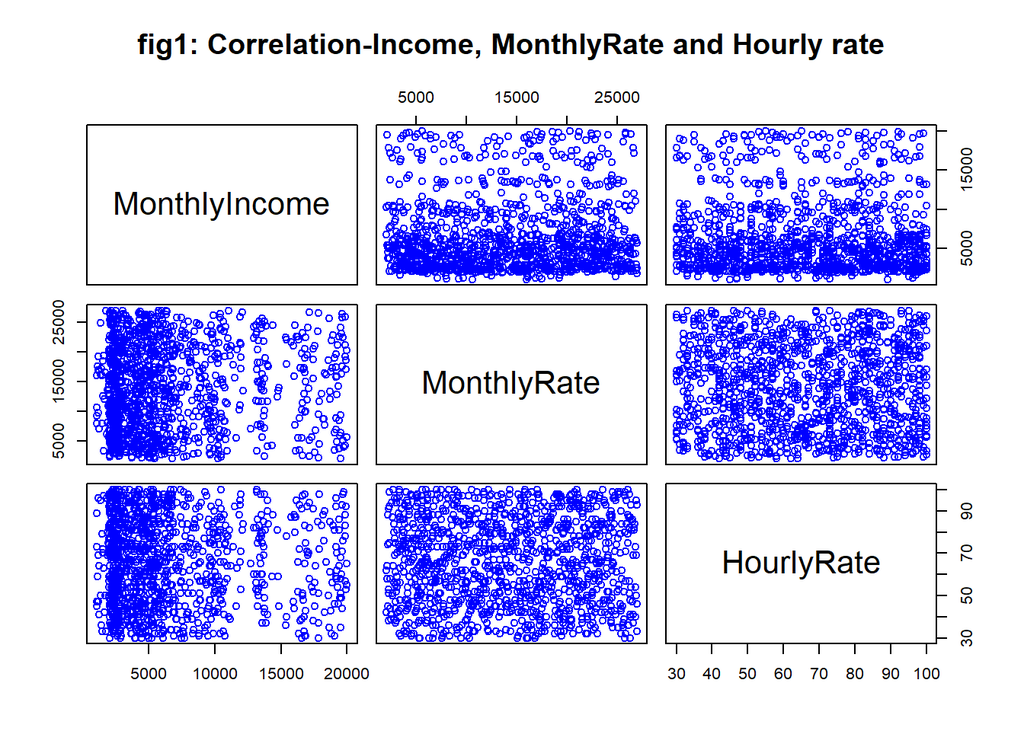

```r
#Using Pairs comparison to find correlation
#Correlation diagram

pairs (~ MonthlyIncome + MonthlyRate + HourlyRate ,
       data = attrition.data ,col=4, main="fig1: Correlation-Income, MonthlyRate and Hourly rate")
```

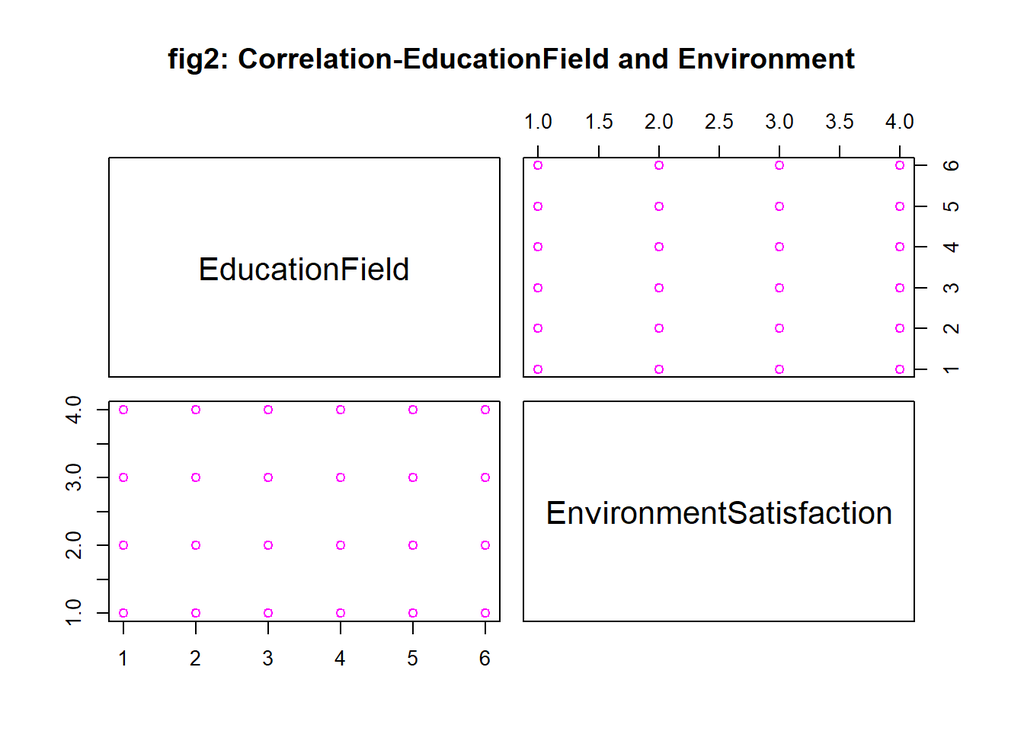

```r
pairs (~EducationField + EnvironmentSatisfaction #+ Gender,
      ,data = attrition.data ,col=6, main="fig2: Correlation-EducationField and Environment")
```

#### Scatter plots association with Attrition

1. fig 3: Scatter plot on Income and Work Life Balance with Attrition
2. fig 4: Scatter plot on Education and Department with Attrition

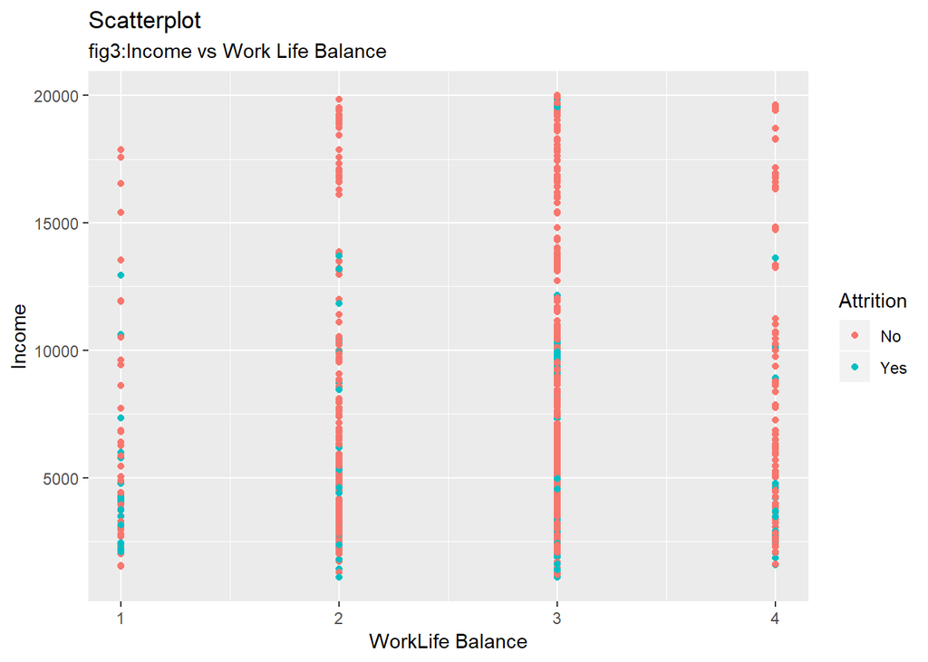

```r
gg1 <- ggplot(attrition.data, aes(x=WorkLifeBalance,                                     y=MonthlyIncome, color = Attrition)) +
       geom_point() +
         labs(subtitle="fig3:Income vs Work Life Balance",
          y="Income",
          x="WorkLife Balance",
          title="Scatterplot")

plot(gg1)
```

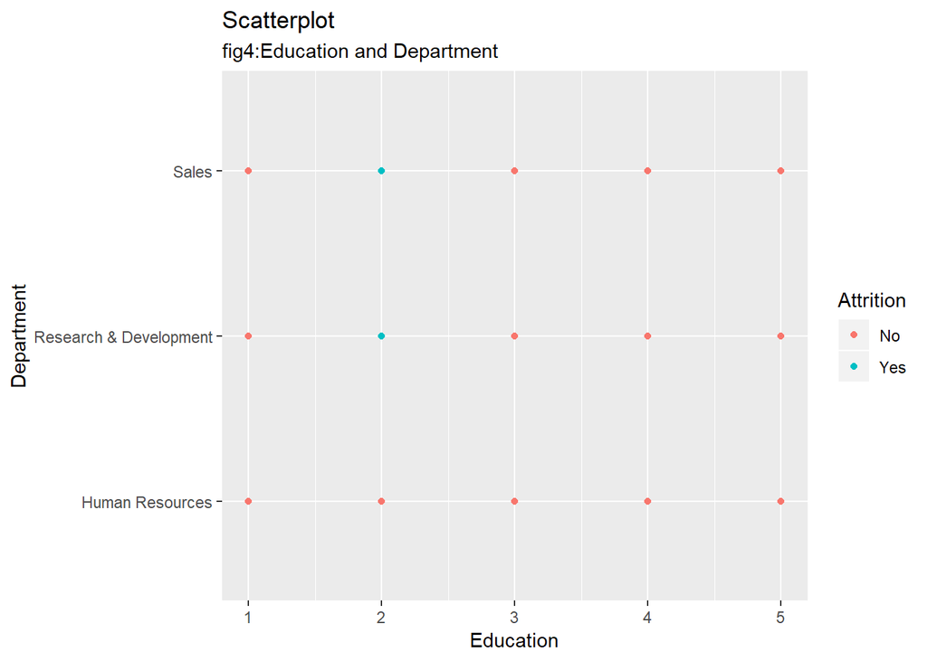

```r
# Attrition per Education & department
gg2 <- ggplot(attrition.data, aes(x=Education, y=Department, color = Attrition)) +
  geom_point() +
    labs(subtitle="fig4:Education and Department",
       y="Department",
       x="Education",
       title="Scatterplot")

plot(gg2)
```

#### Plots to show the Attrition based on monthly income and Job levels.

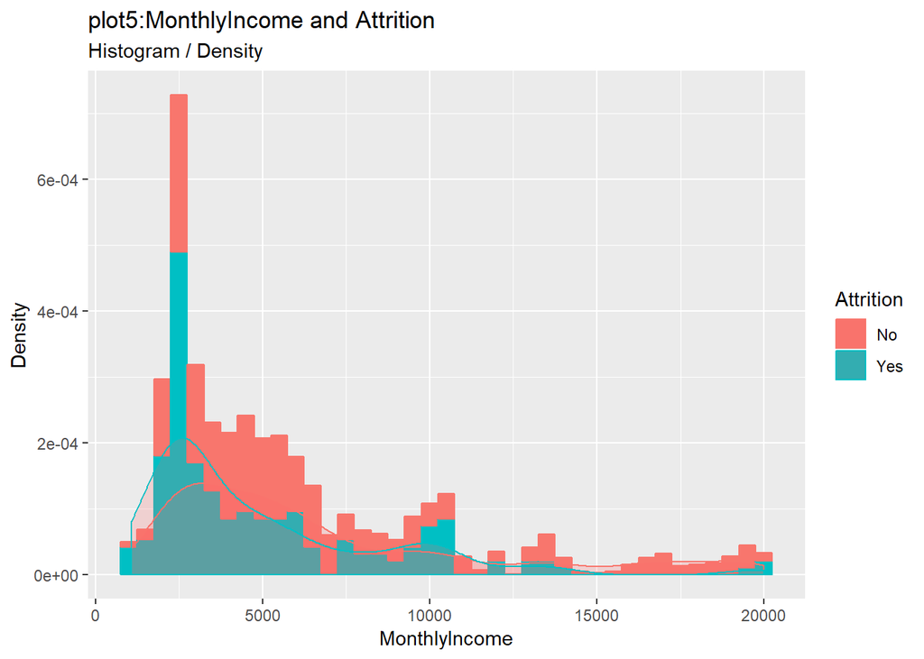

```r
#GG histogram/density between monthly income, and attrition

gg3 <- ggplot(attrition.data, aes(x=MonthlyIncome, fill = Attrition, color = Attrition)) +
  geom_histogram(binwidth = 500, aes(y=..density..)) +
  geom_density(alpha=.2,fill="#FF6666") +
  labs(title="plot5:MonthlyIncome and Attrition",
       y="Density",
       x="MonthlyIncome",
       subtitle="Histogram / Density")

plot(gg3)
```

[figure not shown]

```r
#scatter plot between monthly income, JobLevel and attrition
gg4 <- ggplot(attrition.data, aes(x=attrition.data$JobLevel , y=attrition.data$MonthlyIncome, color = Attrition)) +
  geom_point() +
    labs(subtitle="fig6:Monthly Income and Joblevel",
       y="JobLevel",
       x="Monthly Income",
       title="Scatterplot")
plot(gg4)
```

#Various plots to show Attrition and explanatory variables such as Income, Age, Years of service, Marital status and Years in service with company 1. Bar plot on Years at company and Income level 2. Box plot on Age and attrition 3. Scatter plot on Years at company and Age 4. Box plot on Years Since Last promotion and Attrition 5. Jitter plot on Marital Status and Attrition

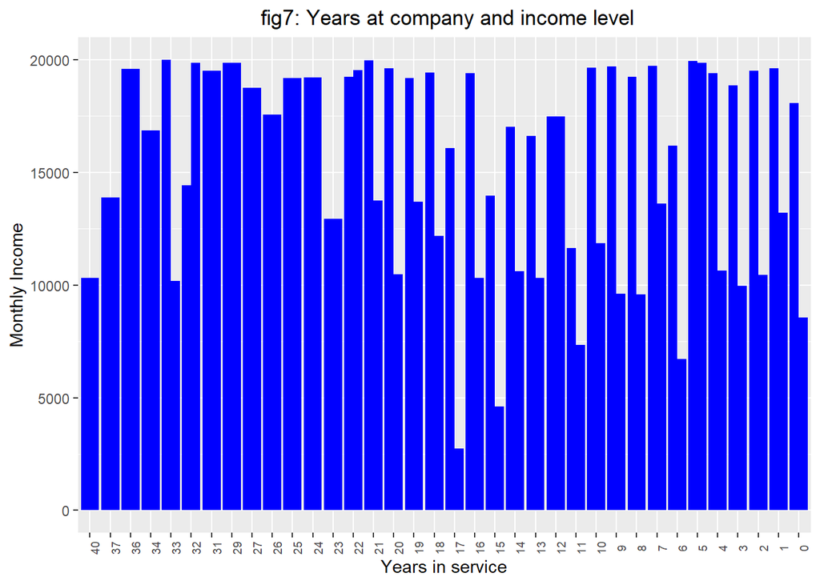

```r
# Plot to show Years at company and Income attrition.

grad <- scales::seq_gradient_pal("blue", "blue")(seq(0,1,length.out=100))

ggplot(attrition.data, aes(x=reorder(attrition.data$YearsAtCompany, -attrition.data$YearsAtCompany), y=attrition.data$MonthlyIncome, fill=Attrition)) +
  geom_bar(stat='identity', position='dodge') +
  labs(title=" fig7: Years at company and income level", x="Years in service", y="Monthly Income") +
  theme(plot.title = element_text(hjust=0.5), axis.text.x=element_text(angle=90, size=7),
        legend.position="none") +
  scale_fill_manual(values=grad)
```

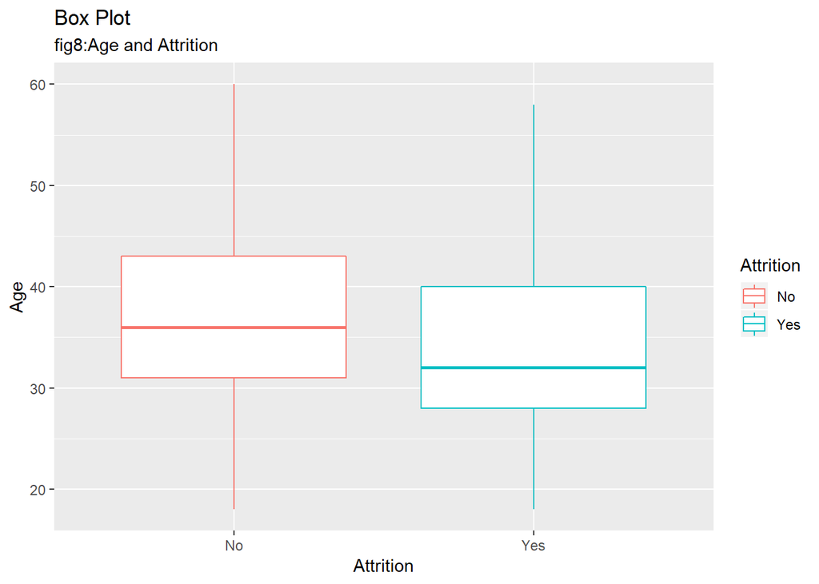

```r
#boxplot between Age and attrition
gg5 <- ggplot(attrition.data, aes(x=Attrition, y=Age, color = Attrition)) +
  geom_boxplot() +
    labs(subtitle="fig8:Age and Attrition",
       y="Age",
       x="Attrition",
       title="Box Plot")
plot(gg5)
```

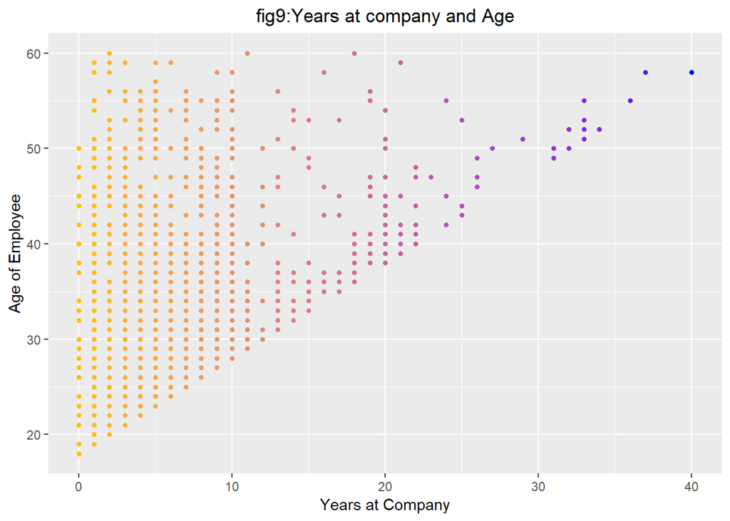

```r
# Scatter plot on Years at company and Age
ggplot(attrition.data, aes(x=YearsAtCompany, y=Age, color=YearsAtCompany)) +
  geom_point(size=1.3, na.rm=TRUE) +
 # geom_smooth(method=lm, na.rm=TRUE, se=FALSE, color="blue") +
  labs(title="fig9:Years at company and Age", x="Years at Company", y="Age of Employee") +
  theme(plot.title = element_text(hjust=0.5), legend.position="none") +
  scale_color_gradient(low = "#ffbf00", high = "blue")
```

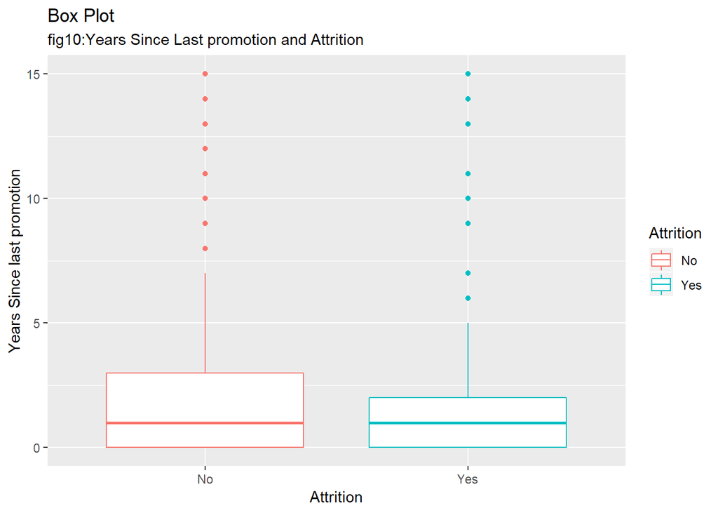

```r
# Years Since Last promotion and Attrition
gg6 <- ggplot(attrition.data, aes(y=YearsSinceLastPromotion, x=Attrition, color = Attrition)) +
  geom_boxplot() +
    labs(subtitle="fig10:Years Since Last promotion and Attrition",
       y="Years Since last promotion",
       x="Attrition",
       title="Box Plot")
plot(gg6)
```

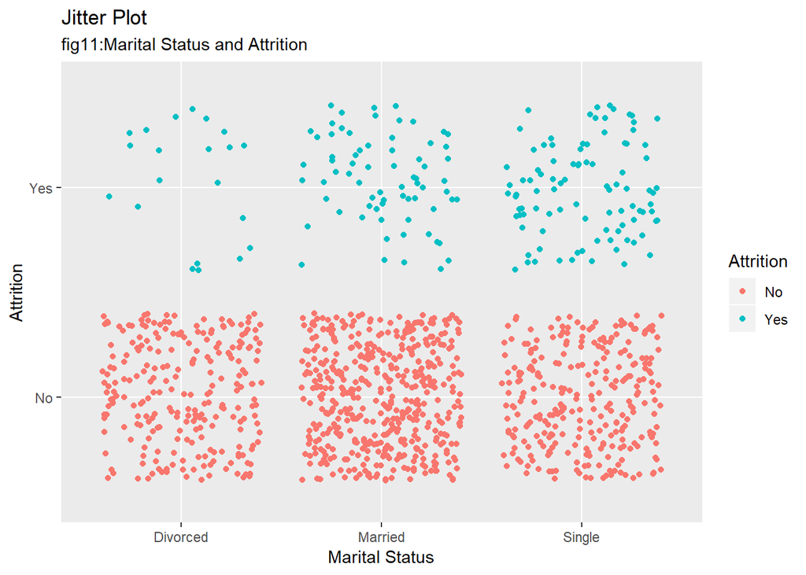

```r
# Jitter plot on Marital Status and Attrition

gg7 <- ggplot(attrition.data, aes(x=MaritalStatus, y=Attrition, color = Attrition)) +
  geom_jitter() +
    labs(subtitle="fig11:Marital Status and Attrition",
       y="Attrition",
       x="Marital Status",
       title="Jitter Plot")
plot(gg7)
```

#### Summary: Elimination of columns not affecting the outcome for training set

We eliminate the columns which have no variance. a. Over18 has no variability, all are Y. b. EmployeeCount has no variability - all are 1. c. StandardHours has no variability - all are 80. d. Employee Number is an identifier. e. Rand is a column generated and unused in the model f. Years at Company has high co-relation with Years in Curr Role g. Total Working Years has a very high co-relation with monthly income h. Years With Current Manager has a very high co-relation with Years in Curr Role

```r
## Removing Cols With High Co-relation

attrition.data$YearsAtCompany <- NULL
attrition.data$TotalWorkingYears <- NULL
attrition.data$YearsWithCurrManager <- NULL

## Moving Attrition Variable to the last column of the data frame

attrition.data$attr <- attrition.data$Attrition

attrition.data$Attrition <- NULL

### Converting all the non numerical factor columns to numerical factors


col.Attrition <- ncol(attrition.data) - 1

for (i in 1:col.Attrition){


      column.class <- sapply(attrition.data[1,i,1],class)
    if (column.class == "factor"){

      column.numeric <- is.numeric(attrition.data[,i])

      if(column.numeric == FALSE){
        attrition.data[,i] <- as.integer(as.factor(attrition.data[,i]))

      }

    }

}
```

#### Using Importance Function that will tell is which are the most important columns in finding the Attrition

```r
# This optimizes the training model
trainc <- trainControl(method="repeatedcv", number=5, repeats=5)

#Creates a model for the learning machine which can be used for predictions on new data.



fitknn=train(attrition.data[1:col.Attrition], attrition.data$attr, method="knn")

impvars=varImp(fitknn, scale=TRUE, nonpara = TRUE, threshold = 0.6)

impvars
```

```
## ROC curve variable importance
##
##   only 20 most important variables shown (out of 27)
##
##                          Importance
## OverTime                     100.00
## MaritalStatus                 91.24
## StockOptionLevel              88.90
## MonthlyIncome                 87.44
## YearsInCurrentRole            86.47
## JobLevel                      84.75
## Age                           78.72
## JobInvolvement                64.15
## EnvironmentSatisfaction       61.29
## JobSatisfaction               45.10
## JobRole                       38.58
## Department                    37.04
## DailyRate                     33.80
## WorkLifeBalance               33.25
## DistanceFromHome              31.20
## TrainingTimesLastYear         27.80
## Gender                        22.61
## NumCompaniesWorked            20.12
## BusinessTravel                16.89
## RelationshipSatisfaction      15.50
```

#### Doing a Permutation Test to find the most effective Combination

```r
## Consider top 10 Factors for Further Analysis

# Now the actual model and prediction

kval <- 5

# Getting the top 10 columns from the Data as per the importance

attr.model <- data.frame(attrition.data[, c(1,19,15,23,16,26,12,11,8,14)]) %>% droplevels()
attr.model$Attrition <- attrition.data$attr


#### Permutation Test to find the higest accuracy

head(attr.model)
```

```
##   Age OverTime MaritalStatus StockOptionLevel MonthlyIncome
## 1  31        1             2                0          2956
## 2  51        1             3                0         13142
## 3  27        1             2                3          1706
## 4  24        1             2                0          3162
## 5  45        2             2                0         13245
## 6  32        1             2                0         10400
##   YearsInCurrentRole JobLevel JobInvolvement EnvironmentSatisfaction
## 1                  0        1              4                       4
## 2                  2        4              2                       4
## 3                  0        1              3                       4
## 4                  2        1              2                       1
## 5                  0        3              3                       4
## 6                  8        3              1                       4
##   JobSatisfaction Attrition
## 1               1       Yes
## 2               2        No
## 3               4        No
## 4               4        No
## 5               1        No
## 6               4       Yes
```

```r
# x = c(1,2,3,4,5,6,7,8)

col.Attrition <- ncol(attr.model)

columns <- seq(1,col.Attrition-1,1)

cols.model <- 5

column.combitations <- combn(columns,cols.model)

Accuracy.table <- as.data.frame(c(1,2),c("A","B"))

combinations <- ncol(column.combitations)

samplesize_attrition = nrow(attr.model)
samplesize_attrition
```

```
## [1] 1170
```

```r
train_perc = .75
train_indices = sample(seq(1,samplesize_attrition,length = samplesize_attrition),train_perc*samplesize_attrition)
Train.Attrition.data = attr.model[train_indices,]
Test.Attrition.data  = attr.model[-train_indices,]

nrow(Train.Attrition.data)
```

```
## [1] 877
```

```r
nrow(Test.Attrition.data)
```

```
## [1] 293
```

```r
for (i in 1:combinations){

  classify.Attrition.data <- Train.Attrition.data
  test.classify.Attrition.data <- Test.Attrition.data

  for (j in 1:cols.model){

    column.class <- sapply(classify.Attrition.data[1,column.combitations[j,i],1],class)
    if (column.class == "factor"){

      column.numeric <- is.numeric(classify.Attrition.data[,column.combitations[j,i]])

      if(column.numeric == FALSE){
        classify.Attrition.data[,column.combitations[j,i]] <- as.integer(as.factor(classify.Attrition.data[,column.combitations[j,i]]))
        test.classify.Attrition.data[,column.combitations[j,i]] <- as.integer(as.factor(test.classify.Attrition.data[,column.combitations[j,i]]))

      }

    }

  }

  cols.knn <- column.combitations[,i]


  results = class::knn(classify.Attrition.data[,cols.knn],
                       test.classify.Attrition.data[,cols.knn],
                       classify.Attrition.data$Attrition,
                       k=kval)

  test.classify.Attrition.data$predictedAttrition <- results

  table(test.classify.Attrition.data$Attrition,test.classify.Attrition.data$predictedAttrition)

  cm <- confusionMatrix(table(test.classify.Attrition.data$Attrition,test.classify.Attrition.data$predictedAttrition))

  Accuracy.table[i,1] <- cm$overall[1]
  Accuracy.table[i,2] <- paste(cols.knn,collapse = " ")

  if (is.integer(i/100) == TRUE){
    Sys.sleep(1)
  }
  print(i)
}
```

```
## [1] 1
## [1] 2
## [1] 3
## [1] 4
## [1] 5
## [1] 6
## [1] 7
## [1] 8
## [1] 9
## [1] 10
## [1] 11
## [1] 12
## [1] 13
## [1] 14
## [1] 15
```

[output cut: 237 more lines]

```r
colnames(Accuracy.table) <- c("Accuracy","Column Num")

Accuracy.table<-arrange(Accuracy.table,desc(Accuracy.table$Accuracy))

head(Accuracy.table)
```

```
##    Accuracy Column Num
## 1 0.8771331 1 2 7 9 10
## 2 0.8771331  1 3 4 7 8
## 3 0.8737201 1 2 4 7 10
## 4 0.8737201 1 7 8 9 10
## 5 0.8737201 3 4 6 7 10
## 6 0.8737201 4 6 7 9 10
```

#### Submitting the Files

```r
#### Converting Overtime Column to Int

attrition.data$OverTime <- as.integer(as.factor(attrition.data$OverTime))

training <- attrition.dataset

samplesize_attrition = nrow(training)

train_perc = .75

train_indices = sample(seq(1,samplesize_attrition,length = samplesize_attrition),train_perc*samplesize_attrition)

dfTrain = as.data.frame(training[train_indices,]) %>% droplevels()

dfVal  = as.data.frame(training[-train_indices,]) %>% droplevels()

dfTrain$OverTime <- as.integer(as.factor(dfTrain$OverTime))
dfVal$OverTime <- as.integer(as.factor(dfVal$OverTime))

#Write CSV file to destination folder

write.csv(dfTrain, file ="dfTrain.csv")

write.csv(dfVal, file="dfVal.csv")


#### The combination of the KNN Model:
#1. Age
#2. Overtime
#3. Job Level
#4. Enviromnment Satisfaction
#5. Job Satisfaction



  results = class::knn(dfTrain[c(2,12,16,18,24)],
                       dfVal[c(2,12,16,18,24)],
                       dfTrain$Attrition,
                       k=kval)


dfVal$PredictedAttrition <- results

table(dfVal$Attrition,dfVal$PredictedAttrition)
```

```
##
##        No Yes
##   No  242   7
##   Yes  40   4
```

```r
#Confushion Matrix creation

cm <- caret::confusionMatrix(table(dfVal$Attrition,dfVal$PredictedAttrition))

cmhd<-head(cm$table)

kable(cmhd, row.names=FALSE, caption="Table 1: Confushion Matrix showing prediction") %>% kable_styling(bootstrap_options="bordered")
```

Table 1: Confushion Matrix showing prediction

| No | Yes |
| --- | --- |
| 242 | 7 |
| 40 | 4 |

```r
cm
```

```
## Confusion Matrix and Statistics
##
##
##        No Yes
##   No  242   7
##   Yes  40   4
##
##                Accuracy : 0.8396
##                  95% CI : (0.7925, 0.8797)
##     No Information Rate : 0.9625
##     P-Value [Acc > NIR] : 1
##
##                   Kappa : 0.0908
##  Mcnemar's Test P-Value : 3.046e-06
##
##             Sensitivity : 0.85816
##             Specificity : 0.36364
##          Pos Pred Value : 0.97189
##          Neg Pred Value : 0.09091
##              Prevalence : 0.96246
##          Detection Rate : 0.82594
##    Detection Prevalence : 0.84983
##       Balanced Accuracy : 0.61090
##
##        'Positive' Class : No
##
```

```r
model_accuracy_knn=sum(dfVal$PredictedAttrition == dfVal$Attrition)/nrow(dfVal)

model_accuracy_knn
```

```
## [1] 0.8395904
```

```r
dfPreds <- data.frame(dfVal$ID,dfVal$PredictedAttrition)

colnames(dfPreds) <- c("ID","PredictedAttrition")

write.csv(dfPreds, file="dfPreds.csv")
```

### Conclusion:

The Management can take the following action to prevent and redduce employee attrition.

1. Preventing the employee from leaving company by identifying the individual with characteristics mentioned.
2. Incentives for work well done and promotions/pay rise
3. More perks
4. Stock options to partake in company profits
5. Employer sponsored events
6. Overtime and work life balance